# A PCA-Based Method to detect Introgression

March 22, 2017

## Introduction

### **Example**

Populus Balsamifera

Populus Trichocarpa

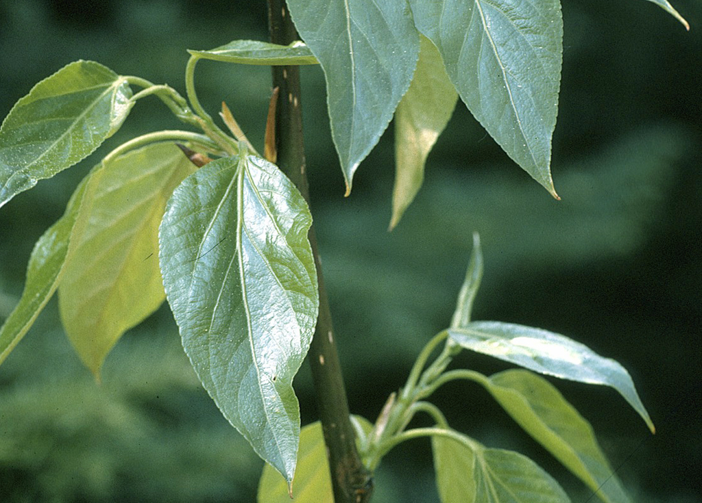

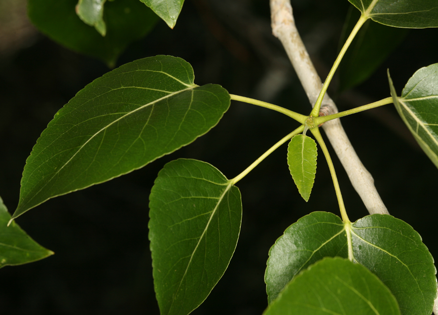

Alaska - Newfoundland

California - Southern Alaska

Low level of precipitations

Moist

High frost tolerance

Mild conditions

## Introduction

### **Example**

Populus hybrid species

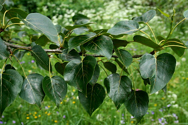

- Faster growth rates
- Cold/Drought tolerance

## Introduction

### **Pipeline**

- SNPs with missing data in the parental genotypes were removed using PLINK 1.07
- Parental genotypes were phased with fastphase and FCGENE
- Model selection: time since admixture, recombination rate
- SNPs ancestries with probabilities higher than 95 percent were considered
- Compute the proportions of both ancestries for each remaining SNP
- Average these proportions using sliding windows along each chromosome

## Introduction

Chromosome 6

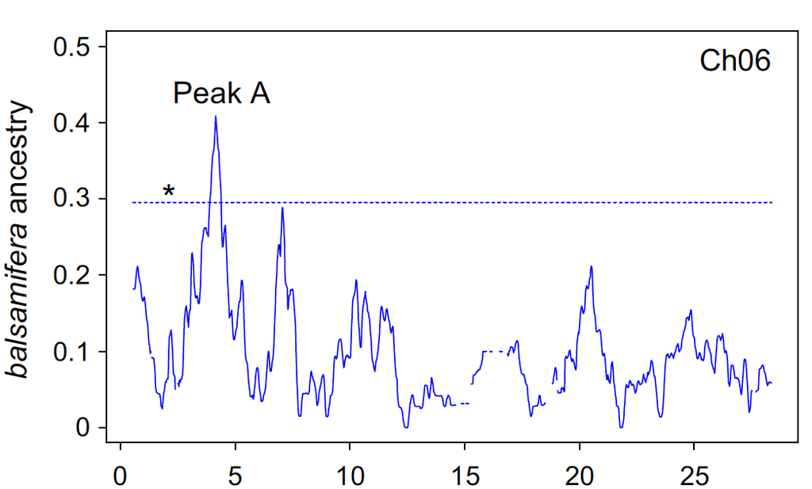

Chromosome 15

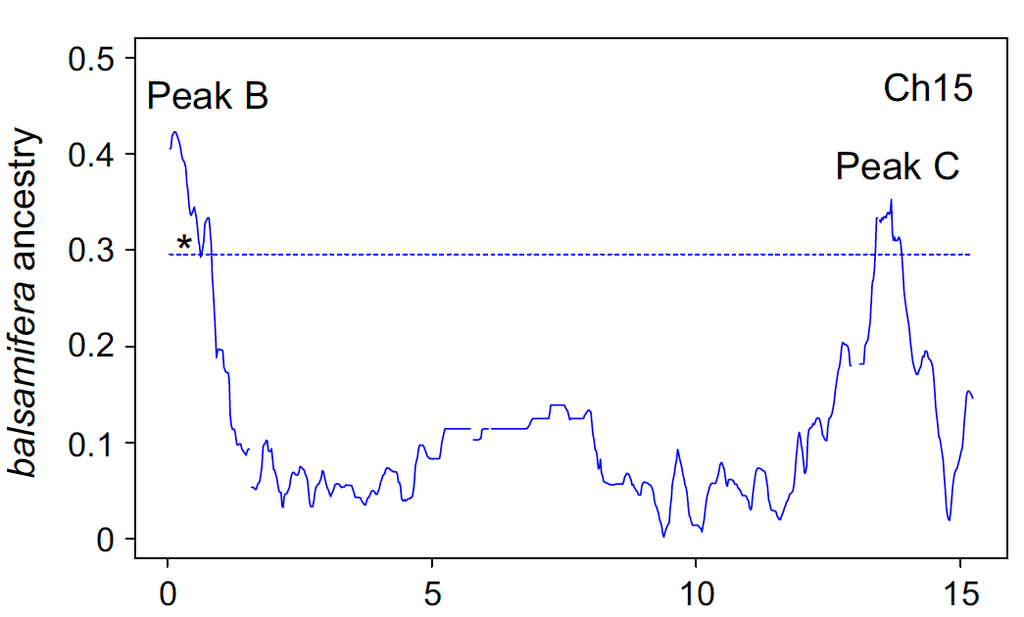

## Method

*"Indeed, many species show chromosome-scale variation in diversity and divergence; species phylogenies can differ along the genome due to incomplete lineage sorting, adaptive introgression and/or local adaptation." (Li, 2016)*

## Method

### **Step 1: Normalization**

Let \(G\) denote the genotype matrix, and \(\tilde{G}\) the normalized genotype matrix such that for SNP \(i\) and individual \(j\):

\[\tilde{G}_{ij} = \frac{G_{ij} - f_i}{\sqrt{2 f_i (1 - f_i)}}\] where \(f_i\) represents the minor allele frequency of SNP \(i\).

### **Step 2: PCA**

\[\tilde{G} = U \Sigma V^T\]

## Method

### **Step 3: "Local PCA"**

Definition: we call *window for SNP* \(i\), and denote it by \(W_i\), any set of SNPs containing SNP \(i\).

For instance:

- the 100 SNPs following SNP \(i\) in the genotype matrix
- the SNPs that are close to SNP \(i\) in terms of genetic distance

## Method

### **Step 3: "Local PCA"**

For SNP \(i\), compute the contribution \(u_i\) of the \(i\)-th window \(W_i\) to the score matrix \(U\):

\[u_i = \tilde{G}_{W_i} V_{W_i} \Sigma^{-1}\]

Up to a constant, \(u_i\) can be seen as a PCA performed on a genotype matrix composed of the SNPs present in \(W_i\).

## Method

```
## Number of SNPs: 1500
## Number of individuals: 150
```

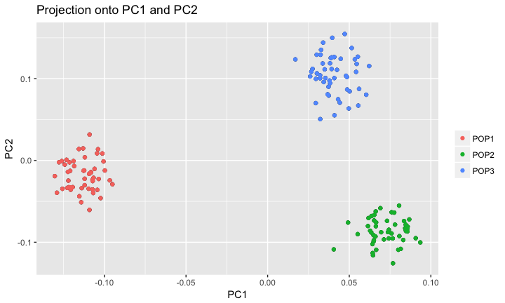

## Method

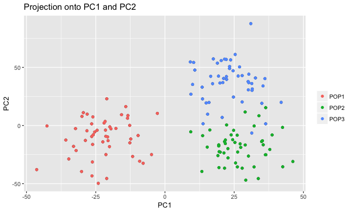

```r
plot(y, option = "scores", pop = pop)
```

## Method

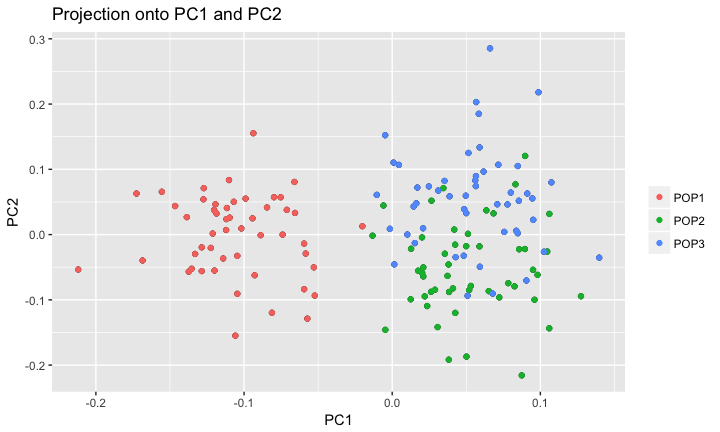

```r
plot(x_local, option = "scores", pop = pop)
```

## Simulations

### **Step 1: Ancestral Haplotypes**

**Beagle:** phase the ancestral haplotypes using the three populations (including the hybrid species)

- Ancestral population 1: Populus Trichocarpa
- Ancestral population 2: Populus Balsamifera
- Admixed population: Populus Trichocarpa Hybrid

## Simulations

### **Step 2: Recombination map**

**vcfR:** extract the physical positions (bp) and convert them into genetic positions (M) using the mean recombination rate.

```
##   PHY        GEN
## 1 410 0.00002050
## 2 411 0.00002055
## 3 416 0.00002080
## 4 450 0.00002250
## 5 452 0.00002260
## 6 453 0.00002265
## 7 480 0.00002400
## 8 488 0.00002440
```

## Simulations

### **Step 3: Generate a hybrid individual**

- Generate the haplotype clusters based on the recombination map

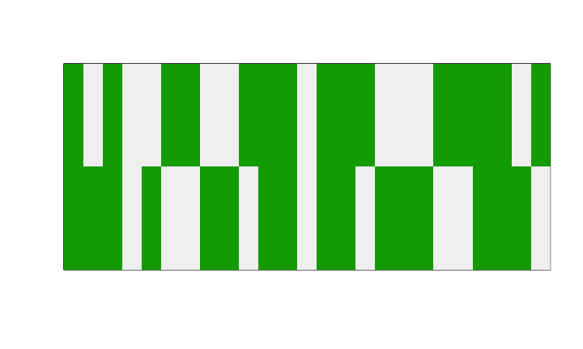